# Reproducible Research Assignment 2

Zach Olivier

June 10, 2017

## NOAA Analysis Snynopsis

Purpose of the analysis is to find what type of events are the most harmful in terms of fatalities and property damage. Data is pulled from the U.S. National Oceanic and Atmospheric Administration (NOAA) storm database. All analysis procedures and steps are listed below.

## Data Processing and Cleaning

First steps is to load the data and prepare it for analysis. Lets read in the file, explore the data using dim and head, and then rename some event types for clarity.

```r
data <- read.csv("/Users/zacholivier/Desktop/RTutorialDataSets/StormData.csv")
data$EVTYPE = toupper(data$EVTYPE)
dim(data)
```

```
## [1] 902297     37
```

```r
head(data)
```

```
##   STATE__           BGN_DATE BGN_TIME TIME_ZONE COUNTY COUNTYNAME STATE
## 1       1  4/18/1950 0:00:00     0130       CST     97     MOBILE    AL
## 2       1  4/18/1950 0:00:00     0145       CST      3    BALDWIN    AL
## 3       1  2/20/1951 0:00:00     1600       CST     57    FAYETTE    AL
## 4       1   6/8/1951 0:00:00     0900       CST     89    MADISON    AL
## 5       1 11/15/1951 0:00:00     1500       CST     43    CULLMAN    AL
## 6       1 11/15/1951 0:00:00     2000       CST     77 LAUDERDALE    AL
##    EVTYPE BGN_RANGE BGN_AZI BGN_LOCATI END_DATE END_TIME COUNTY_END
## 1 TORNADO         0                                               0
## 2 TORNADO         0                                               0
## 3 TORNADO         0                                               0
## 4 TORNADO         0                                               0
## 5 TORNADO         0                                               0
## 6 TORNADO         0                                               0
##   COUNTYENDN END_RANGE END_AZI END_LOCATI LENGTH WIDTH F MAG FATALITIES
```

[output cut: 20 more lines]

```r
data[data$EVTYPE == "TSTM WIND", ]$EVTYPE = "THUNDERSTORM WIND"
data[data$EVTYPE == "THUNDERSTORM WINDS", ]$EVTYPE = "THUNDERSTORM WIND"
data[data$EVTYPE == "RIVER FLOOD", ]$EVTYPE = "FLOOD"
data[data$EVTYPE == "HURRICANE/TYPHOON", ]$EVTYPE = "HURRICANE-TYPHOON"
data[data$EVTYPE == "HURRICANE", ]$EVTYPE = "HURRICANE-TYPHOON"
```

## Event Analysis

Lets dig into the data to see which events are most harmful. In the data set, there are multiple types of damage; fatality, injury, property damage, crop damage. The first set of code aggregates the data to see which has the highest totals of each type of damage. Finally, let’s plot each to see if there any connections between all types of damage.

```r
#fatality summary
fataldat <- aggregate(FATALITIES ~ EVTYPE, data = data, sum)
fatal1 <- fataldat[fataldat$FATALITIES > 0, ]
fatallist <- fatal1[order(fatal1$FATALITIES, decreasing = TRUE), ]
head(fatallist)
```

```
##                EVTYPE FATALITIES
## 755           TORNADO       5633
## 116    EXCESSIVE HEAT       1903
## 138       FLASH FLOOD        978
## 243              HEAT        937
## 417         LIGHTNING        816
## 683 THUNDERSTORM WIND        701
```

```r
#injury summary
injurydat <- aggregate(INJURIES ~ EVTYPE, data = data, sum)
injury1 <- injurydat[injurydat$INJURIES > 0, ]
injurylist <- injury1[order(injury1$INJURIES, decreasing = TRUE), ]
head(injurylist)
```

```
##                EVTYPE INJURIES
## 755           TORNADO    91346
## 683 THUNDERSTORM WIND     9353
## 154             FLOOD     6791
## 116    EXCESSIVE HEAT     6525
## 417         LIGHTNING     5230
## 243              HEAT     2100
```

```r
#property damage summary
propdat <- aggregate(PROPDMG ~ EVTYPE, data = data, sum)
prop1 <- propdat[propdat$PROPDMG > 0, ]
proplist <- prop1[order(prop1$PROPDMG, decreasing = TRUE), ]
head(proplist)
```

```
##                EVTYPE   PROPDMG
## 755           TORNADO 3212258.2
## 683 THUNDERSTORM WIND 2659133.0
## 138       FLASH FLOOD 1420124.6
## 154             FLOOD  913794.2
## 212              HAIL  688693.4
## 417         LIGHTNING  603351.8
```

```r
#crop damage summary
cropdat <- aggregate(CROPDMG ~ EVTYPE, data = data, sum)
crop1 <- cropdat[cropdat$CROPDMG > 0, ]
croplist <- crop1[order(crop1$CROPDMG, decreasing = TRUE), ]
head(croplist)
```

```
##                EVTYPE   CROPDMG
## 212              HAIL 579596.28
## 683 THUNDERSTORM WIND 194678.98
## 138       FLASH FLOOD 179200.46
## 154             FLOOD 171527.88
## 755           TORNADO 100018.52
## 84            DROUGHT  33898.62
```

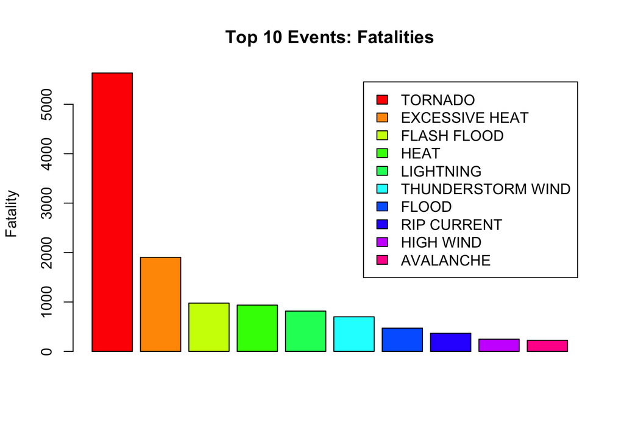

```r
#fatality chart
barplot(fatallist[1:10, 2],col = rainbow(10), legend.text = fatallist[1:10,
    1], ylab = "Fatality", main = "Top 10 Events: Fatalities")
```

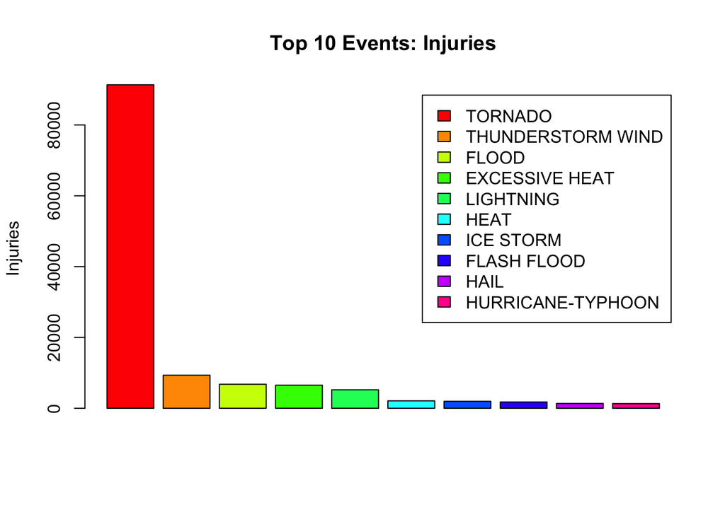

```r
#injury chart
barplot(injurylist[1:10, 2],col = rainbow(10),  legend.text = injurylist[1:10,
    1], ylab = "Injuries", main = "Top 10 Events: Injuries")
```

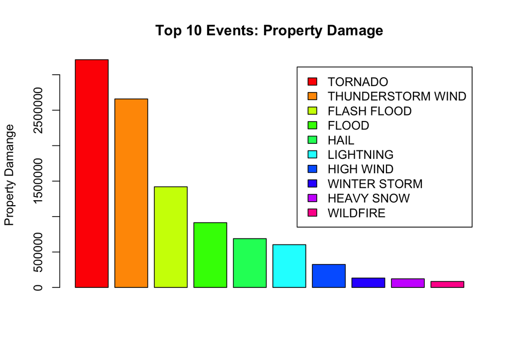

```r
#property damage chart
barplot(proplist[1:10, 2],col = rainbow(10), legend.text = proplist[1:10,
    1], ylab = "Property Damange", main = "Top 10 Events: Property Damage")
```

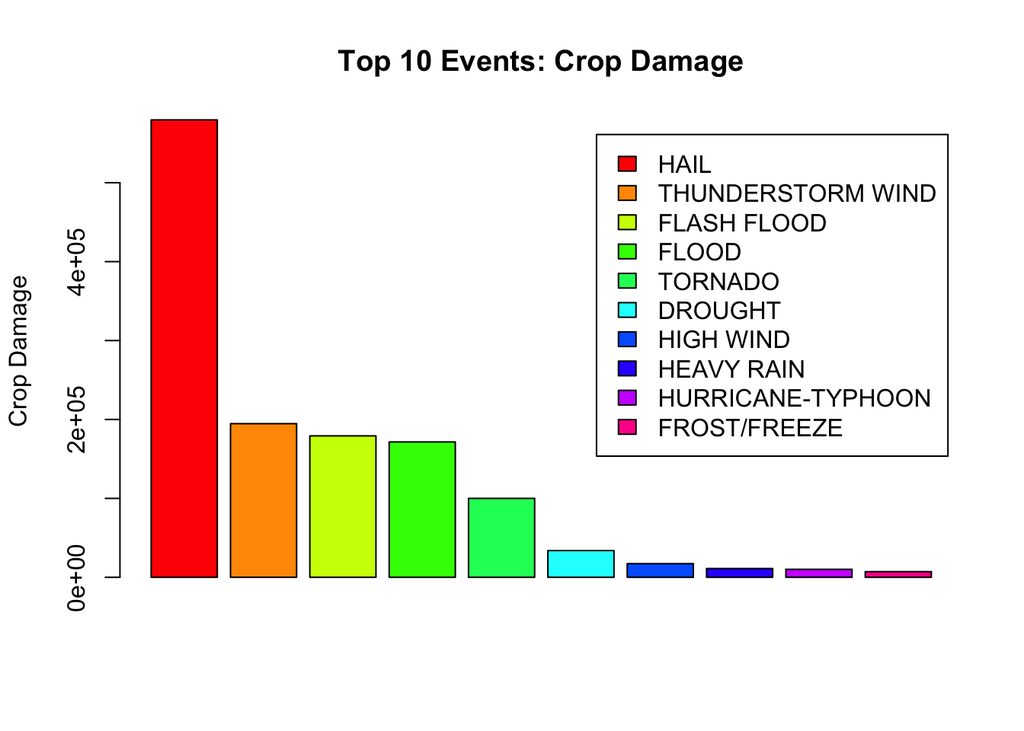

```r
#crop damage chart
barplot(croplist[1:10, 2],col = rainbow(10), legend.text = croplist[1:10,
    1], ylab = "Crop Damage", main = "Top 10 Events: Crop Damage")
```